# Drug death analysis

Isabella Liu

● Introduction (.5-1 page of text, 25 pts):

○ Introduce (in words) the dataset and question (5 pts)

○ 1-2 key plots or tables illustrating your exploratory data analysis (10 pts)

○ Description and justification of the methodology you will use in your analysis (10 pts)

# Introduction

The dataset I found on Kaggle was about Drug overdose deaths which includes accidental drug related deaths during 2012-2018. As described in the metadata, the rate of overdose deaths in Connecticut increased from 9.9 per 100,000 residents in 2012 to 28.5 per 100,000 residents in 2018-a 221 % increase-with the majority occurring among persons aged 35-64 (65.3 %), men (73.9 %), and non-Hispanic whites (78.5 %). Among deaths involving fentanyl, the overall deaths escalated from 5.2 deaths per 100,000 residents in 2015 to 21.3 deaths per 100,000 residents in 2018 and more than 50% of these fentanyl-related deaths involved polysubstance use.

Procedures:

First I would like to do EDA on the dataset to get general idea of the data such that what features are contained and how are they distributed.

Second, apply smoothing, regression, and associated tests on the potential questions I am interested in:

- how are drugs overdoes deaths distributed in and related to gender, age, race, time and the location that he/she has dead?
- what drug causes the most death?
- predict the death likelihood based on the drugs people use?

# EDA

```r
#load packages
library(tidyr)
library(tidyverse)
library(data.table)
library(caret)
```

```r
library(ggplot2)
library(dplyr)
library(lubridate)
library(janitor)
library(scales)
library(ggrepel)
library(tidytext)
library(viridis)
#load data
df <- read.csv("drug_deaths.csv")
df %>% summary()
```

```
##        X             ID                Date              DateType
##  Min.   :   0   Length:5105        Length:5105        Min.   :0.000
##  1st Qu.:1276   Class :character   Class :character   1st Qu.:0.000
##  Median :2552   Mode  :character   Mode  :character   Median :0.000
##  Mean   :2552                                         Mean   :0.447
##  3rd Qu.:3828                                         3rd Qu.:1.000
##  Max.   :5104                                         Max.   :1.000
##                                                       NA's   :2
##       Age            Sex                Race           ResidenceCity
##  Min.   :14.00   Length:5105        Length:5105        Length:5105
##  1st Qu.:32.00   Class :character   Class :character   Class :character
##  Median :42.00   Mode  :character   Mode  :character   Mode  :character
##  Mean   :41.96
##  3rd Qu.:52.00
##  Max.   :87.00
##  NA's   :3
##  ResidenceCounty    ResidenceState      DeathCity         DeathCounty
##  Length:5105        Length:5105        Length:5105        Length:5105
##  Class :character   Class :character   Class :character   Class :character
##  Mode  :character   Mode  :character   Mode  :character   Mode  :character
##
##
##
##
##    Location         LocationifOther    DescriptionofInjury InjuryPlace
##  Length:5105        Length:5105        Length:5105         Length:5105
##  Class :character   Class :character   Class :character    Class :character
##  Mode  :character   Mode  :character   Mode  :character    Mode  :character
##
##
##
##
##   InjuryCity        InjuryCounty       InjuryState            COD
##  Length:5105        Length:5105        Length:5105        Length:5105
##  Class :character   Class :character   Class :character   Class :character
##  Mode  :character   Mode  :character   Mode  :character   Mode  :character
##
##
##
##
```

[output cut: 33 more lines]

```
##  Min.   :0.00000   Length:5105        Length:5105        Length:5105
##  1st Qu.:0.00000   Class :character   Class :character   Class :character
##  Median :0.00000   Mode  :character   Mode  :character   Mode  :character
##  Mean   :0.01724
##  3rd Qu.:0.00000
##  Max.   :1.00000
##
##  ResidenceCityGeo   InjuryCityGeo
##  Length:5105        Length:5105
##  Class :character   Class :character
##  Mode  :character   Mode  :character
##
##
##
##
```

```r
# How does the dataset look like
head(df)
```

```
##   X      ID                   Date DateType Age    Sex         Race
## 1 0 14-0273 06/28/2014 12:00:00 AM        1  NA
## 2 1 13-0102 03/21/2013 12:00:00 AM        0  48   Male        Black
## 3 2 16-0165 03/13/2016 12:00:00 AM        0  30 Female        White
## 4 3 16-0208 03/31/2016 12:00:00 AM        0  23   Male        White
## 5 4 13-0052 02/13/2013 12:00:00 AM        0  22   Male Asian, Other
## 6 5 14-0277 06/29/2014 12:00:00 AM        0  23   Male        White
##   ResidenceCity ResidenceCounty ResidenceState DeathCity DeathCounty  Location
## 1
## 2       NORWALK                                  NORWALK   FAIRFIELD  Hospital
## 3    SANDY HOOK       FAIRFIELD             CT   DANBURY              Hospital
## 4           RYE     WESTCHESTER             NY GREENWICH              Hospital
## 5      FLUSHING          QUEENS                GREENWICH   FAIRFIELD  Hospital
## 6       BRISTOL                                  BRISTOL    HARTFORD Residence
##   LocationifOther    DescriptionofInjury InjuryPlace InjuryCity InjuryCounty
```

[output cut: 41 more lines]

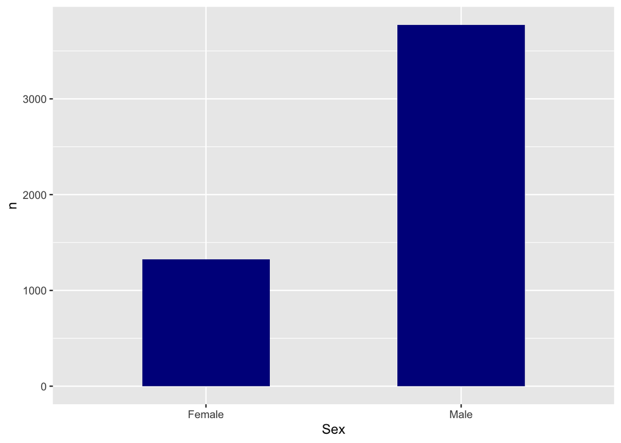

```r
#features with value count
# age, race, gender, cause of death
df%>% group_by(Sex)%>%filter(Sex!="Unknown"&Sex!="")%>%summarise(n=n())%>%ggplot(aes(x=Sex, y=n)) +
  geom_bar(stat="identity",fill="darkblue",width=0.5)
```

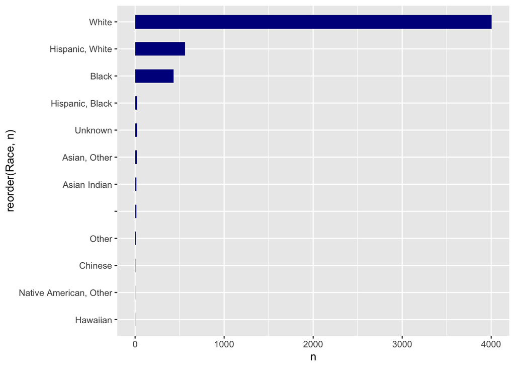

```r
df%>% group_by(Race)%>%summarise(n=n())%>%ggplot(aes(x=reorder(Race,n), y=n)) +
  geom_bar(stat="identity",fill="darkblue",width=0.5)+coord_flip()
```

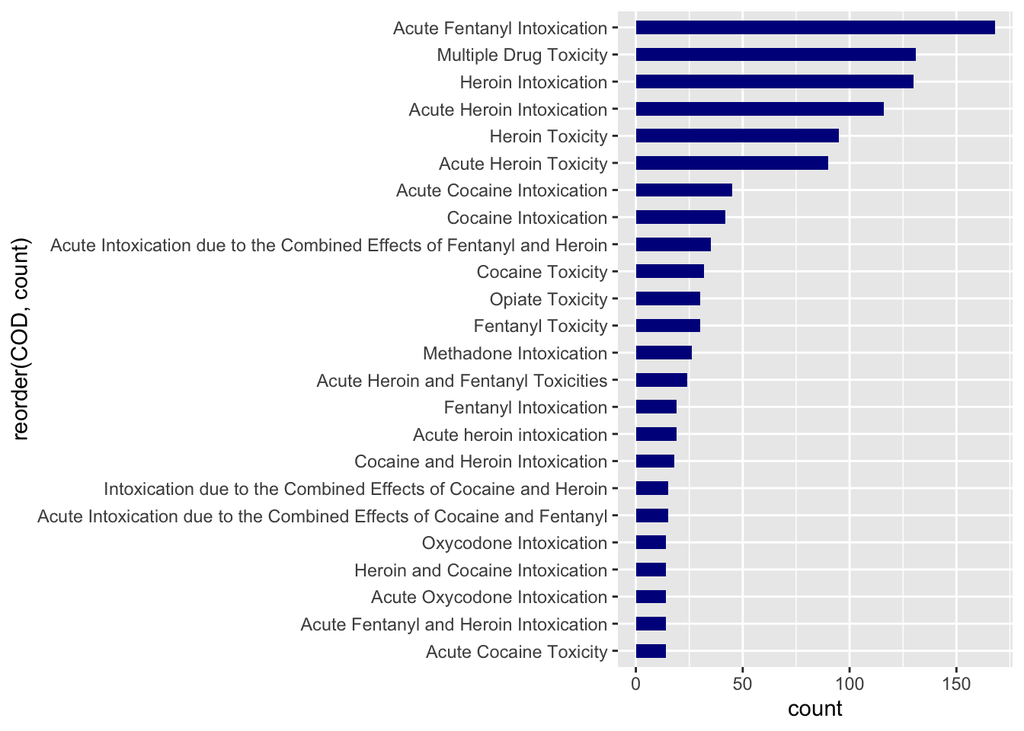

```r
cod<- df%>% group_by(COD)%>%summarise(count=n())%>%arrange(desc(count))
top_n(cod, n=20, count) %>%
          ggplot(., aes(x=reorder(COD,count), y=count))+
              geom_bar(stat='identity',fill="darkblue",width=0.5)+coord_flip()
```

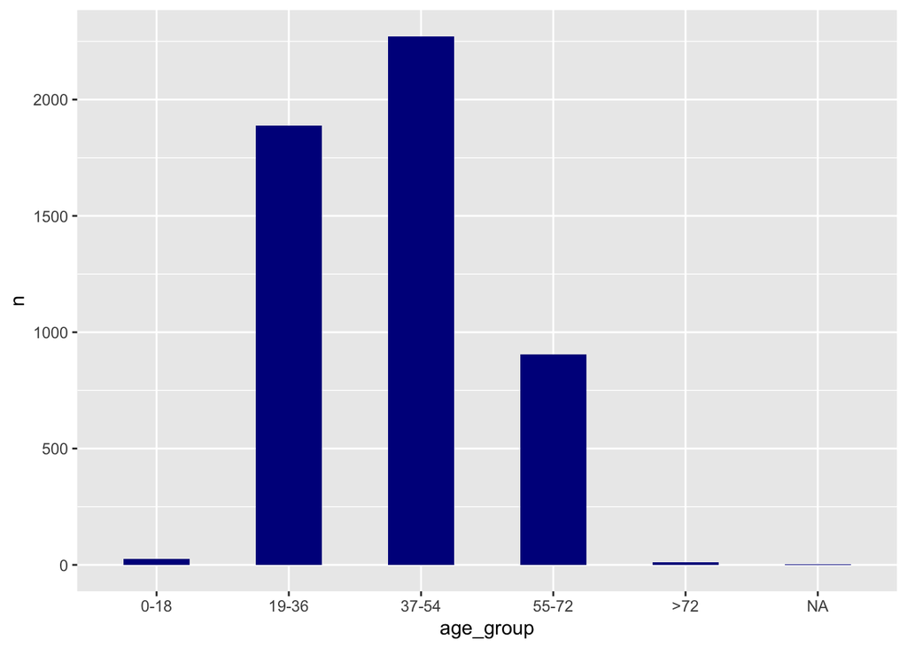

```r
age<-df %>%
  mutate(
    # Create categories
    age_group = dplyr::case_when(
      Age <= 18            ~ "0-18",
      Age > 18 & Age <= 36 ~ "19-36",
      Age > 36 & Age <= 54 ~ "37-54",
      Age > 54 & Age <=72   ~ "55-72",
      Age >72 ~ ">72"
    ),
    # Convert to factor
    age_group = factor(
      age_group,
      level = c("0-18", "19-36","37-54", "55-72",">72")
    )
  )
age%>% group_by(age_group)%>%summarise(n=n())%>%ggplot(aes(x=age_group, y=n)) +
  geom_bar(stat="identity",fill="darkblue",width=0.5)
```

After the EDA, I noticed there are a lot of missing data and the data is not quite clean as there are different ways to describe the same cause of death in the COD column, but essentially we are interested in the drug that cause the death. Also the some of the same values are written in both upper and lower cases. The drug variables are binary values which would be useful if they are combined in one column. There are many NAs as well but not in the columns that I’m interested in regarding this study, so I would leave them there for the moment.

# data processing

```r
df$Fentanyl <- as.numeric(as.character(df$Fentanyl))
df$Morphine_NotHeroin<-as.numeric(as.character(df$Morphine_NotHeroin))
df2 <-
  df %>% select(
    "ID",
    "Date",
    "ResidenceState",
    "Age",
    "Race",
    "Sex",
    "COD",
    "MannerofDeath",
    "Location",
    "Heroin",
    "Fentanyl",
    "Fentanyl_Analogue",
    "Morphine_NotHeroin",
    "Cocaine",
    "Oxycodone",
    "Oxymorphone",
    "Ethanol",
    "Hydrocodone",
    "Benzodiazepine",
    "Methadone",
    "Amphet",
    "Tramad",
    "Hydromorphone"
  ) %>%
  pivot_longer(
    cols = c(
    "Heroin",
    "Fentanyl",
    "Fentanyl_Analogue",
    "Morphine_NotHeroin",
    "Cocaine",
    "Oxycodone",
    "Oxymorphone",
    "Ethanol",
    "Hydrocodone",
    "Benzodiazepine",
    "Methadone",
    "Amphet",
    "Tramad",
    "Hydromorphone"
    ),
    names_to = "drug_name",
    values_to = "value",
    values_drop_na = TRUE,
  )
```

The new table contains 71462 rows and 11 columns which is much longer than the original dataset which contains 5105 unique observations. That’s because some of the people in the data had used more than one drug.

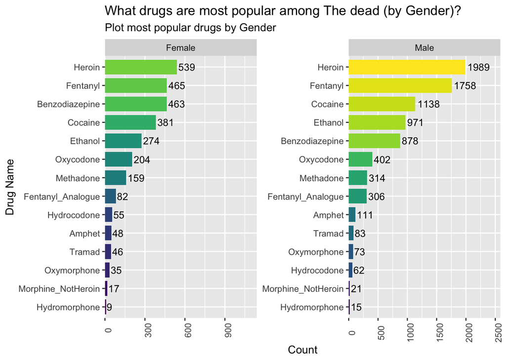

```r
df2 %>%
  filter(value != 0,
         Sex != "Unknown",
         Sex !="") %>%
  group_by(drug_name, Sex) %>%
  summarise(Count = sum(value), .groups = "drop") %>%
  ungroup() %>%
  mutate(sex = as.factor(Sex),
         drug_name = reorder_within(drug_name, Count, Sex)) %>%
  mutate(countsum = sum(Count)) %>%
  ggplot(aes(
    x = fct_reorder(drug_name, Count),
    y = Count,
    label = Count,
    fill = drug_name
  )) +
  geom_col(width = 0.8) +
  scale_y_continuous(expand = expansion(add = c(0, 600))) +
  geom_text(hjust = -0.1, size = 3.5) +
  coord_flip() +
  scale_x_reordered() +
  facet_wrap(vars(Sex), scales = "free") +
  theme(legend.position = "none") +
  theme(axis.text.x = element_text(angle = 90)) +
  scale_fill_viridis(discrete = TRUE, option = "D")+
  labs(
    title = "What drugs are most popular among The dead (by Gender)?",
    subtitle = "Plot most popular drugs by Gender",
    x = "Drug Name",
    y = "Count"
  )
```

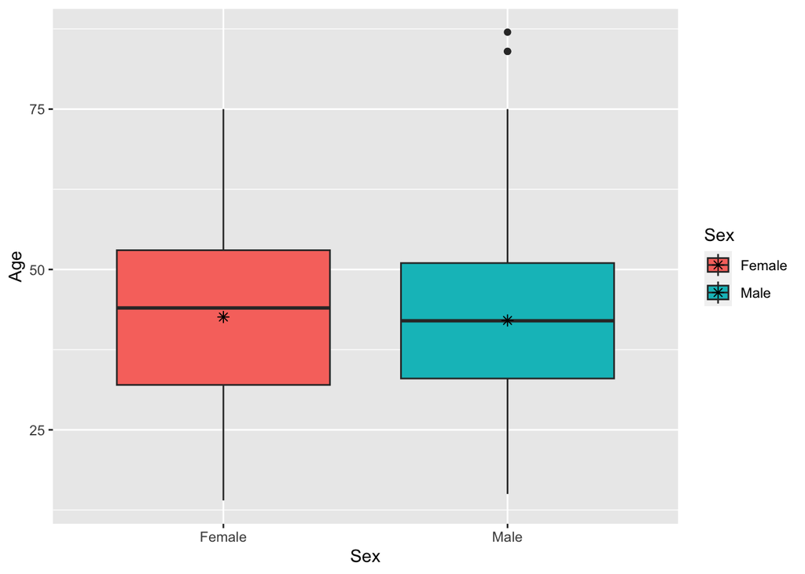

```r
df2 %>%
  filter(value != 0,
         Sex != "Unknown",
         Sex !="") %>%
  ggplot(aes(x = Sex, y = Age, fill=Sex)) +
  geom_boxplot() +
  stat_summary(fun = "mean", geom = "point", shape = 8,
               size = 2, color = "black")
```